# Coursera - Practical Machine Learning Project

Conrad Frank

22 September 2018

# Introduction

Using devices such as Jawbone Up, Nike FuelBand, and Fitbit it is now possible to collect a large amount of data about personal activity relatively inexpensively. These type of devices are part of the quantified self movement – a group of enthusiasts who take measurements about themselves regularly to improve their health, to find patterns in their behavior, or because they are tech geeks. One thing that people regularly do is quantify how much of a particular activity they do, but they rarely quantify how well they do it.

In this project, our goal will be to use data from accelerometers on the belt, forearm, arm, and dumbell of 6 participants. They were asked to perform barbell lifts correctly and incorrectly in 5 different ways. They are classified as : exactly according to the specification **(Class A)**, throwing the elbows to the front **(Class B)**, lifting the dumbbell only halfway **(Class C)**, lowering the dumbbell only halfway **(Class D)** and throwing the hips to the front **(Class E)**.

Information is derived from url : http://groupware.les.inf.puc-rio.br/har

## Data Processing

```r
library(caret)
library(rattle)
library(parallel)
library(doParallel)

### Settting seed for reproducibility
set.seed(123456)
```

## Loading data

Loading training dataset from below url

```r
if(!file.exists("./data")){dir.create("./data")}
if(!file.exists("./data/pml-training.csv") ){
  url  <- "https://d396qusza40orc.cloudfront.net/predmachlearn/pml-training.csv"
  download.file(url , destfile = "./data/pml-training.csv", method = "curl")
}
```

Loading test dataset from below url

```r
if(!file.exists("./data/pml-testing.csv") ){
  url  <- "https://d396qusza40orc.cloudfront.net/predmachlearn/pml-testing.csv"
  download.file(url , destfile = "./data/pml-testing.csv", method = "curl")
}
```

## Reading Data

```r
training_orginal <- read.csv("./data/pml-training.csv")
testing_original <- read.csv("./data/pml-testing.csv")
dim(training_orginal); dim(testing_original)
```

```
[1] 19622   160
```

```
[1]  20 160
```

The goal of this project is to predict the manner in which they did the exercise, i.e using the *“classe”* variable in the training set to predict the outcome from testing set.

## Cleaning the data

There are 160 variables in training and test dataset, we have to check for covariates that have no variability

```r
var_nzv <- nearZeroVar(training_orginal, saveMetrics = TRUE)

# Number of NZV covariates to be deleted
sum(var_nzv$nzv==TRUE)
```

```
[1] 60
```

```r
#Creating new training dataset woithout NZV variables
training_NZV <- training_orginal[var_nzv$nzv==FALSE]
dim(training_NZV)
```

```
[1] 19622   100
```

Removing columns with NA values and also extraneous columns

```r
training_new <- training_NZV[,colSums(is.na(training_NZV))==0]
training_new <- training_new[ , -c(1:7)]
dim(training_new)
```

```
[1] 19622    52
```

Using same steps to clean the test dataset

```r
testing_NZV <- testing_original[var_nzv$nzv==FALSE]
testing_new <- testing_NZV[,colSums(is.na(testing_NZV))==0]
testing_new <- testing_new[ , -c(1:7)]
dim(testing_new)
```

```
[1] 20 52
```

New training dataset has 19622 observations with 52 variables and new testing dataset has 20 observations with 52 variables. The outcome variable ‘**classe**’ still present in new training set.

## Splicing training data set

The test set has to be used in the ‘*Course Project Prediction Quiz Portion*’ with our best machine learning algorithm which has to be predicted. Since our new training set is large and test set very small, we will split the new training set into secondary training (70%) and and test sets (30%) to validate the various ML algorithm predictions. This will help in reducing processing time.

```r
inTrain <- createDataPartition(training_new$classe, p = 0.70, list=F)
training <- training_new[inTrain,]
testing <- training_new[-inTrain,]
dim(training); dim(testing)
```

```
[1] 13737    52
```

```
[1] 5885   52
```

## Data Models

We will be building 3 different models using the *‘train’* function from **caret** library:

**‘Classification tree’** - using method - *rpart* , **‘Gradient boosting method’** - using method - *gbm* , **‘Random forest’** - using method - *rf*

In order to improve the efficiency of the models and reduce processing time especially for Random Forest model, we use **‘cross-validation’** technique with **5-folds**. As mentioned in discussion forum, parallel processing technique will be used using the **parallel** and **doParallel** libraries, to drastically reduce the processing time in RF model.

### Train with Classification tree

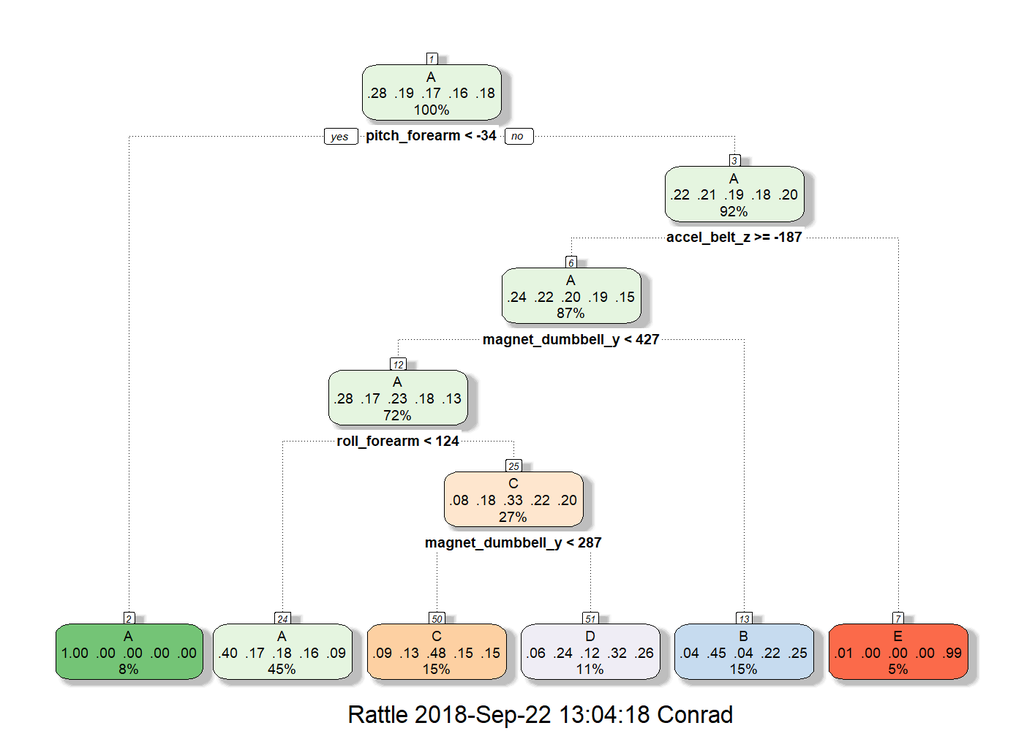

```r
fitControl <- trainControl(method = "cv",number = 5,allowParallel = TRUE)
modelct <- train(classe~., data=training,trControl = fitControl, method = "rpart")

#display modeel_CT
fancyRpartPlot(modelct$finalModel)
```

```r
predict_ct <- predict(modelct,testing)
confMat_ct <- confusionMatrix(testing$classe,predict_ct)

#displaying confusion matrix and accuracy
confMat_ct$table
```

```
          Reference
Prediction    A    B    C    D    E
         A 1523   38   85   28    0
         B  456  416  122  145    0
         C  468   50  424   84    0
         D  429  175  132  228    0
         E  246  260  139  137  300
```

```r
confMat_ct$overall[1]
```

```
 Accuracy
0.4912489
```

### Train with Gradient boosting method

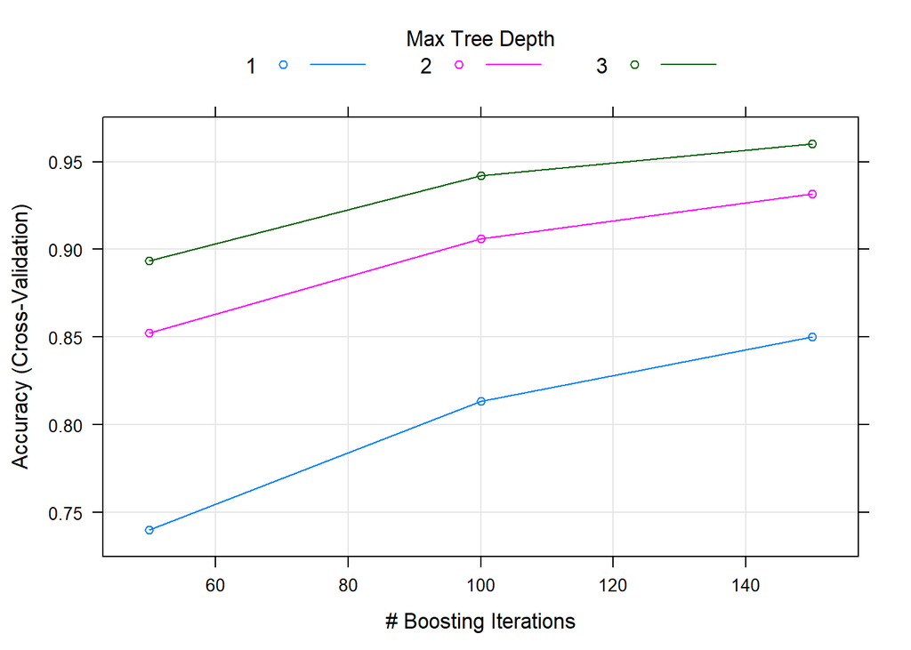

```r
modelgbm <- train(classe~., data=training,trControl = fitControl, method = "gbm", verbose = FALSE)

plot(modelgbm)
```

```r
predict_gbm <- predict(modelgbm,testing)
confMat_gbm <- confusionMatrix(testing$classe,predict_gbm)

#displaying confusion matrix and accuracy
confMat_gbm$table
```

```
          Reference
Prediction    A    B    C    D    E
         A 1646   19    3    4    2
         B   40 1070   22    1    6
         C    1   36  971   17    1
         D    0    1   37  921    5
         E    1   11   10   18 1042
```

```r
confMat_gbm$overall[1]
```

```
Accuracy
0.960068
```

Getting very good accuracy 96% using cross-validation with 5-folds. Let us check with RF to see if the accuracy can be improved.

### Train with Random Forest method

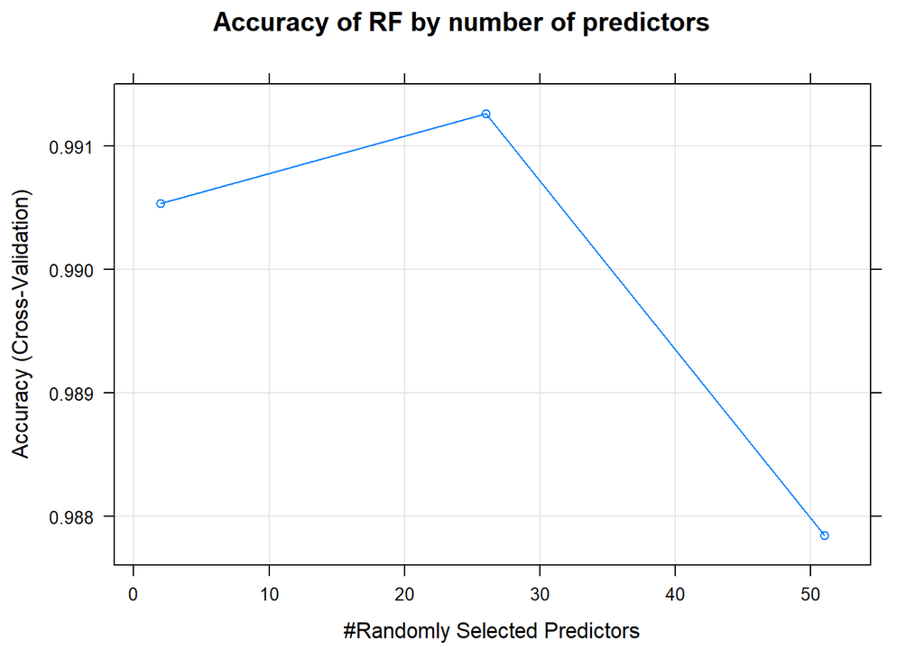

```r
#setting up for parallel processing
library(parallel)
library(doParallel)
cluster <- makeCluster(detectCores() - 1) # convention to leave 1 core for OS
registerDoParallel(cluster)

modelrf <- train(classe~., data=training,trControl = fitControl, method = "rf")

stopCluster(cluster)
registerDoSEQ()

plot(modelrf, main = "Accuracy of RF by number of predictors")
```

```r
predict_rf <- predict(modelrf,testing)
confMat_rf <- confusionMatrix(testing$classe,predict_rf)


#displaying confusion matrix and accuracy
confMat_rf$table
```

```
          Reference
Prediction    A    B    C    D    E
         A 1674    0    0    0    0
         B   10 1127    2    0    0
         C    0    9 1017    0    0
         D    0    0    9  955    0
         E    0    0    1    2 1079
```

```r
confMat_rf$overall[1]
```

```
 Accuracy
0.9943925
```

```r
#displaying the important variables
MostImpVar <- varImp(modelrf)
MostImpVar
```

```
rf variable importance

  only 20 most important variables shown (out of 51)

                     Overall
yaw_belt              100.00
pitch_forearm          85.10
pitch_belt             70.12
magnet_dumbbell_z      67.14
magnet_dumbbell_y      56.78
roll_forearm           52.17
accel_belt_z           40.91
magnet_belt_y          28.40
magnet_belt_z          27.90
gyros_belt_z           27.71
magnet_dumbbell_x      27.22
accel_dumbbell_y       26.02
roll_dumbbell          25.72
accel_forearm_x        23.17
total_accel_dumbbell   19.60
magnet_belt_x          18.79
accel_dumbbell_z       18.36
magnet_forearm_z       16.67
yaw_arm                15.66
accel_forearm_z        13.57
```

# Conclusion

Random Forest is giving >99% accuracy, we will use this methods to predict the values of classe for the original test data set.

The outcome will used as submission in ‘*Course Project Prediction Quiz Portion*’

```r
#predict using RF model
predict_final_rf <- predict(modelrf,testing_new)
predict_final_rf
```

```
 [1] B A B A A E D B A A B C B A E E A B B B
Levels: A B C D E
```